# NRL Round Summary

Generated: 2026-10-05 14:12  
Model: lean_v2_hard_team_player_router | Recent form window: last 4 games

## Sydney Roosters v Newcastle Knights

Bet 2026-10-04 19:30 | Accor Stadium, Sydney

Preferred model **TEAM : +5.7** Home margin. TEAM selected by default; JOINT published as PLAYER diagnostic

TEAM / PLAYER margins **+5.7 / +8.0** Expected player advantage: n/a ; lineup coverage 97 %

Model line / market **-5.7 vs -7.5** Edge: Newcastle Knights by 1.8 pts ( Lean )

Model total / market **48.0 vs 42.5** Edge: Over by 5.5 pts ( Bet )

Total volatility **High volatility, 1.22x comp avg** Observed scoring in games featuring these teams

Margin volatility **Normal volatility, 1.04x comp avg** Alt watch: Alt total.

**Rain:** Forecast rain 0.0mm; projected rain impact: total n/a, line n/a.

Model says this is playable at the current number. Recent form below uses only current-season games before this fixture.

### Sydney Roosters

Scoreboard: 28.5 scored / 24.8 conceded.  
Expectation check: +3.1 vs model, +10.2 vs market. Higher is better.  
Last 4 totals: +4.4 vs weather-adjusted model, +6.5 vs market. Games are landing above expectation.

- **Ins:** Benaiah Ioelu, Cody Ramsey
- **Outs:** Connor Watson, Nat Butcher

### Newcastle Knights

Scoreboard: 21.5 scored / 20.0 conceded.  
Expectation check: +7.8 vs model, +8.5 vs market. Higher is better.  
Last 4 totals: -8.6 vs weather-adjusted model, -4.0 vs market. Games are landing below expectation.

- **Ins:** Diesel Hagan, Fletcher Hunt, Thomas Cant
- **Outs:** Lachlan Crouch, Pasami Saulo, Phoenix Crossland

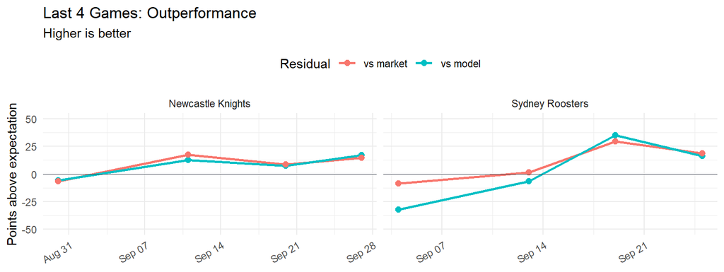

### Last 4 Games: Full Game Totals

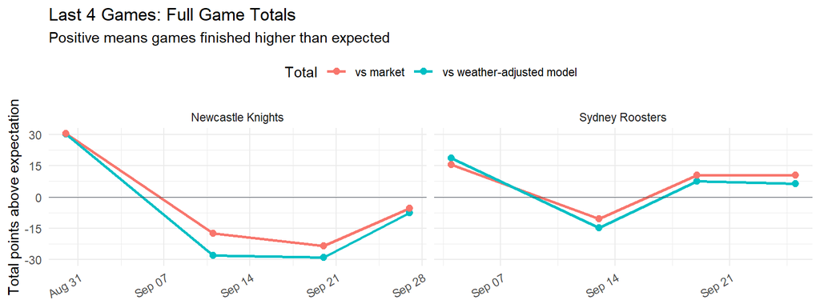

### Strong Try Matchups

**Sydney Roosters** rate well on the right centre through Billy Smith against Newcastle Knights ( 1.56 x).

**Newcastle Knights** rate well on the right wing through Dominic Young against Sydney Roosters ( 1.29 x).